# Lab: Bioconductor tools for mass spectrometry and proteomics

# 2 How does mass spectrometry work?

Mass spectrometry (MS) is a technology that *separates* charged molecules (ions) based on their mass to charge ratio (M/Z). It is often coupled to chromatography (liquid LC, but can also be gas-based GC). The time an analytes takes to elute from the chromatography column is the *retention time*.

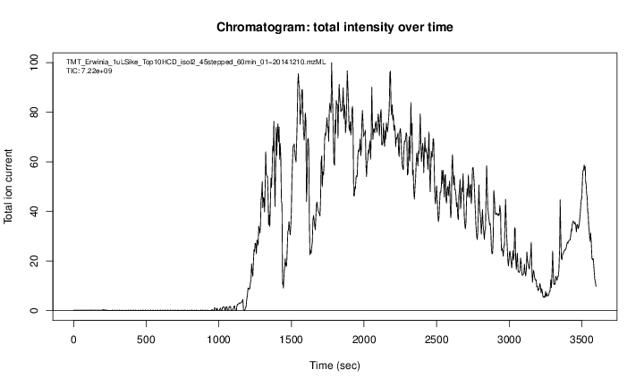

A chromatogram, illustrating the total amount of analytes over the retention time.

An mass spectrometer is composed of three components:

1. The *source*, that ionises the molecules: examples are Matrix-assisted laser desorption/ionisation (MALDI) or electrospray ionisation. (ESI)
2. The *analyser*, that separates the ions: Time of flight (TOF) or Orbitrap.
3. The *detector* that quantifies the ions.

When using mass spectrometry for proteomics, the proteins are first digested with a protease such as trypsin. In mass shotgun proteomics, the analytes assayed in the mass spectrometer are peptides.

Often, ions are subjected to more than a single MS round. After a first round of separation, the peaks in the spectra, called MS1 spectra, represent peptides. At this stage, the only information we possess about these peptides are their retention time and their mass-to-charge (we can also infer their charge be inspecting their isotopic envelope, i.e the peaks of the individual isotopes, see below), which is not enough to infer their identify (i.e. their sequence).

In MSMS (or MS2), the settings of the mass spectrometer are set automatically to select a certain number of MS1 peaks (for example 20). Once a narrow M/Z range has been selected (corresponding to one high-intensity peak, a peptide, and some background noise), it is fragmented (using for example collision-induced dissociation (CID), higher energy collisional dissociation (HCD) or electron-transfer dissociation (ETD)). The fragment ions are then themselves separated in the analyser to produce a MS2 spectrum. The unique fragment ion pattern can then be used to infer the peptide sequence using de novo sequencing (when the spectrum is of high enough quality) of using a search engine such as, for example Mascot, MSGF+, …, that will match the observed, experimental spectrum to theoratical spectra (see details below).

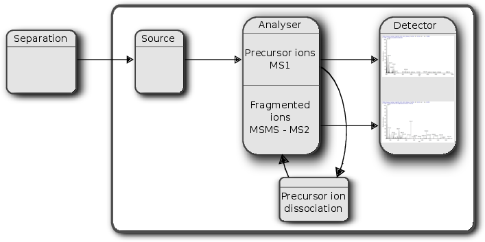

Schematics of a mass spectrometer and two rounds of MS.

The animation below show how 25 ions different ions (i.e. having different M/Z values) are separated throughout the MS analysis and are eventually detected (i.e. quantified). The final frame shows the hypothetical spectrum.

[figure not shown]

Separation and detection of ions in a mass spectrometer.

The figures below illustrate the two rounds of MS. The spectrum on the left is an MS1 spectrum acquired after 21 minutes and 3 seconds of elution. 10 peaks, highlited by dotted vertical lines, were selected for MS2 analysis. The peak at M/Z 460.79 (488.8) is highlighted by a red (orange) vertical line on the MS1 spectrum and the fragment spectra are shown on the MS2 spectrum on the top (bottom) right figure.

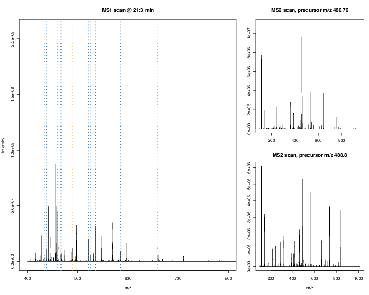

Parent ions in the MS1 spectrum (left) and two sected fragment ions MS2 spectra (right).

The figures below represent the 3 dimensions of MS data: a set of spectra (M/Z and intensity) of retention time, as well as the interleaved nature of MS1 and MS2 (and there could be more levels) data.

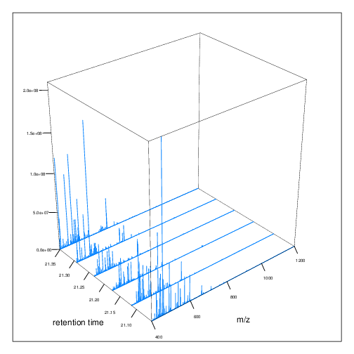

MS1 spectra over retention time.

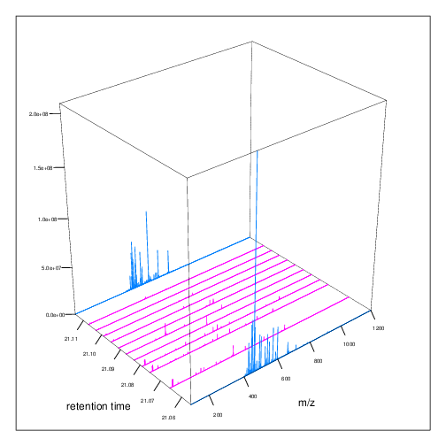

MS2 spectra interleaved between two MS1 spectra.

# 3 Accessing data

## 3.1 From the ProteomeXchange database

On-line

MS-based proteomics data is disseminated through the [ProteomeXchange](http://www.proteomexchange.org/) infrastructure, which centrally coordinates submission, storage and dissemination through multiple data repositories, such as the [PRoteomics IDEntifications (PRIDE)](https://www.ebi.ac.uk/pride/archive/) database at the EBI for mass spectrometry-based experiments (including quantitative data, as opposed as the name suggests), [PASSEL](http://www.peptideatlas.org/passel/) at the ISB for Selected Reaction Monitoring (SRM, i.e. targeted) data and the [MassIVE](http://massive.ucsd.edu/ProteoSAFe/static/massive.jsp) resource. These data can be downloaded within R using the *rpx* package.

```r
library("rpx")
pxannounced()
```

```
## 15 new ProteomeXchange annoucements
```

```
##     Data.Set    Publication.Data             Message
## 1  PXD007736 2018-07-10 19:59:06                 New
## 2  PXD010366 2018-07-10 15:49:29                 New
## 3  PXD009158 2018-07-10 15:47:16                 New
## 4  PXD007122 2018-07-10 09:35:52                 New
## 5  PXD010346 2018-07-10 04:09:06                 New
## 6  PXD010345 2018-07-09 16:41:16                 New
## 7  PXD010344 2018-07-09 16:41:06                 New
## 8  PXD009495 2018-07-09 07:22:36                 New
## 9  PXD009826 2018-07-06 14:39:06                 New
## 10 PXD009939 2018-07-06 12:39:44                 New
## 11 PXD007761 2018-07-06 12:38:09 Updated information
## 12 PXD005923 2018-07-06 10:00:35 Updated information
## 13 PXD008069 2018-07-06 07:27:24                 New
## 14 PXD005973 2018-07-05 17:28:53                 New
## 15 PXD008592 2018-07-05 17:25:40                 New
```

Using the unique `PXD000001` identifier, we can retrieve the relevant metadata that will be stored in a `PXDataset` object. The names of the files available in this data can be retrieved with the `pxfiles` accessor function.

```r
px <- PXDataset("PXD000001")
px
```

```
## Object of class "PXDataset"
##  Id: PXD000001 with 12 files
##  [1] 'F063721.dat' ... [12] 'generated'
##  Use 'pxfiles(.)' to see all files.
```

```r
pxfiles(px)
```

```
##  [1] "F063721.dat"
##  [2] "F063721.dat-mztab.txt"
##  [3] "PRIDE_Exp_Complete_Ac_22134.xml.gz"
##  [4] "PRIDE_Exp_mzData_Ac_22134.xml.gz"
##  [5] "PXD000001_mztab.txt"
##  [6] "README.txt"
##  [7] "TMT_Erwinia_1uLSike_Top10HCD_isol2_45stepped_60min_01-20141210.mzML"
##  [8] "TMT_Erwinia_1uLSike_Top10HCD_isol2_45stepped_60min_01-20141210.mzXML"
##  [9] "TMT_Erwinia_1uLSike_Top10HCD_isol2_45stepped_60min_01.mzXML"
## [10] "TMT_Erwinia_1uLSike_Top10HCD_isol2_45stepped_60min_01.raw"
## [11] "erwinia_carotovora.fasta"
## [12] "generated"
```

Other metadata for the `px` data set:

```r
pxtax(px)
```

```
## [1] "Erwinia carotovora"
```

```r
pxurl(px)
```

```
## [1] "ftp://ftp.pride.ebi.ac.uk/pride/data/archive/2012/03/PXD000001"
```

```r
pxref(px)
```

```
## [1] "Gatto L, Christoforou A. Using R and Bioconductor for proteomics data analysis. Biochim Biophys Acta. 2014 1844(1 pt a):42-51"
```

Data files can then be downloaded with the `pxget` function. Below, we retrieve the raw data file. The file is downloaded in the working directory and the name of the file is return by the function and stored in the `mzf` variable for later use .

If the file is already available, it is not downloaded a second time.

This and other files are also availabel in the `msdata` package, described below

```r
fn <- "TMT_Erwinia_1uLSike_Top10HCD_isol2_45stepped_60min_01-20141210.mzML"
mzf <- pxget(px, fn)
```

```
## /home/lg390/Documents/Teaching/bioc-ms-prot/TMT_Erwinia_1uLSike_Top10HCD_isol2_45stepped_60min_01-20141210.mzML already present.
```

```r
mzf
```

```
## [1] "/home/lg390/Documents/Teaching/bioc-ms-prot/TMT_Erwinia_1uLSike_Top10HCD_isol2_45stepped_60min_01-20141210.mzML"
```

## 3.2 From AnnotationHub

On-line

*AnnotationHub* is a cloud resource set up and managed by the Bioconductor project that serves various omics datasets. It is possible to contribute and access (albeit currently only a limited number of) [proteomics data](http://bioconductor.org/packages/devel/bioc/vignettes/ProteomicsAnnotationHubData/inst/doc/ProteomicsAnnotationHubData.html).

```r
library("AnnotationHub")
ah <- AnnotationHub()
```

```
## snapshotDate(): 2018-04-30
```

```r
query(ah, "proteomics")
```

```
## AnnotationHub with 4 records
## # snapshotDate(): 2018-04-30
## # $dataprovider: PRIDE
## # $species: Erwinia carotovora
## # $rdataclass: AAStringSet, MSnSet, mzRident, mzRpwiz
## # additional mcols(): taxonomyid, genome, description,
## #   coordinate_1_based, maintainer, rdatadateadded, preparerclass,
## #   tags, rdatapath, sourceurl, sourcetype
## # retrieve records with, e.g., 'object[["AH49006"]]'
##
##             title
##   AH49006 | PXD000001: Erwinia carotovora and spiked-in protein fasta file
##   AH49007 | PXD000001: Peptide-level quantitation data
##   AH49008 | PXD000001: raw mass spectrometry data
##   AH49009 | PXD000001: MS-GF+ identiciation data
```

```r
ms <- ah[["AH49008"]]
ms
```

```
## Mass Spectrometry file handle.
## Filename:  55314
## Number of scans:  7534
```

The data contains 7534 spectra - 1431 MS1 spectra and 6103 MS2 spectra. The file name, 55314, is not very descriptive because the data originates from the `AnnotationHub` cloud repository. If the data was read from a local file, is would be named as the `mzML` (or `mzXML`) file (see below).

## 3.3 Data packages

Some data are also distributed through dedicated packages. The *msdata*, for example, provides some general raw data files relevant for both proteomics and metabolomics.

```r
library("msdata")
## proteomics raw data
proteomics()
```

```
## [1] "MRM-standmix-5.mzML.gz"
## [2] "MS3TMT10_01022016_32917-33481.mzML.gz"
## [3] "MS3TMT11.mzML"
## [4] "TMT_Erwinia_1uLSike_Top10HCD_isol2_45stepped_60min_01-20141210.mzML.gz"
## [5] "TMT_Erwinia_1uLSike_Top10HCD_isol2_45stepped_60min_01.mzML.gz"
```

```r
## proteomics identification data
ident()
```

```
## [1] "TMT_Erwinia_1uLSike_Top10HCD_isol2_45stepped_60min_01-20141210.mzid"
```

More often, such *experiment packages* distribute processed data; an example of such is the *pRolocdata* package, that offers quantitative proteomics data.

# 4 Raw MS data

## 4.1 High-level data structures

The *MSnbase* package provides high-level data abstractions for raw MS data through the `MSnExp` class and containers for quantification data via the `MSnSet` class (see *Quantitative proteomics* section). Both store

1. the actual assay data (spectra or quantitation matrix, see below), accessed with `spectra` (or the `[`, `[[` operators) or `exprs`;
2. sample metadata, accessed as a `data.frame` with `pData`;
3. feature metadata, accessed as a `data.frame` with `fData`.

Another useful slot is `processingData`, accessed with `processingData(.)`, that records all the processing that objects have undergone since their creation (see examples below).

## 4.2 Raw data: the `MSnExp` class

The `readMSData` will parse the raw data and construct an MS experiment object of class `MSnExp`. An important argument to `readMSData` is the *mode*, which can be `"onDisk"` or `"inMemory"`. The former doesn’t load the raw data in memory (which is not advised for MS1 data, or when many files are loaded) and is generally the recommended mode. See the `benchmarking` vignette for details).

Open it with `vignette("benchmarking", package = "MSnbase")` or read it [online](https://bioconductor.org/packages/release/bioc/vignettes/MSnbase/inst/doc/benchmarking.html)

```r
library("MSnbase")
## get a small test data
rawFile <- dir(system.file(package = "MSnbase", dir = "extdata"),
               full.name = TRUE, pattern = "mzXML$")
basename(rawFile)
```

```
## [1] "dummyiTRAQ.mzXML"
```

```r
msexp <- readMSData(rawFile, msLevel = 2L)
msexp
```

```
## MSn experiment data ("MSnExp")
## Object size in memory: 0.18 Mb
## - - - Spectra data - - -
##  MS level(s): 2
##  Number of spectra: 5
##  MSn retention times: 25:1 - 25:2 minutes
## - - - Processing information - - -
## Data loaded: Wed Jul 11 08:58:03 2018
##  MSnbase version: 2.6.1
## - - - Meta data  - - -
## phenoData
##   rowNames: dummyiTRAQ.mzXML
##   varLabels: sampleNames
##   varMetadata: labelDescription
## Loaded from:
##   dummyiTRAQ.mzXML
## protocolData: none
## featureData
##   featureNames: F1.S1 F1.S2 ... F1.S5 (5 total)
##   fvarLabels: spectrum
##   fvarMetadata: labelDescription
## experimentData: use 'experimentData(object)'
```

Spectra can be extracted as a list of `Spectrum2` objects with the `spectra` accessor or as a subset of the original `MSnExp` data with the `[` operator. Individual spectra can be accessed with `[[`.

```r
length(msexp)
```

```
## [1] 5
```

```r
msexp[1:2]
```

```
## MSn experiment data ("MSnExp")
## Object size in memory: 0.07 Mb
## - - - Spectra data - - -
##  MS level(s): 2
##  Number of spectra: 2
##  MSn retention times: 25:1 - 25:2 minutes
## - - - Processing information - - -
## Data loaded: Wed Jul 11 08:58:03 2018
## Data [numerically] subsetted 2 spectra: Wed Jul 11 08:58:03 2018
##  MSnbase version: 2.6.1
## - - - Meta data  - - -
## phenoData
##   rowNames: dummyiTRAQ.mzXML
##   varLabels: sampleNames
##   varMetadata: labelDescription
## Loaded from:
##   dummyiTRAQ.mzXML
## protocolData: none
## featureData
##   featureNames: F1.S1 F1.S2
##   fvarLabels: spectrum
##   fvarMetadata: labelDescription
## experimentData: use 'experimentData(object)'
```

```r
msexp[[2]]
```

```
## Object of class "Spectrum2"
##  Precursor: 546.9586
##  Retention time: 25:2
##  Charge: 3
##  MSn level: 2
##  Peaks count: 1012
##  Total ion count: 56758067
```

The identification results stemming from the same raw data file can then be used to add PSM matches.

```r
## initial feature variable
fData(msexp)
```

```
##       spectrum
## F1.S1        1
## F1.S2        2
## F1.S3        3
## F1.S4        4
## F1.S5        5
```

```r
## find path to a mzIdentML file
identFile <- dir(system.file(package = "MSnbase", dir = "extdata"),
                 full.name = TRUE, pattern = "dummyiTRAQ.mzid")
basename(identFile)
```

```
## [1] "dummyiTRAQ.mzid"
```

```r
msexp <- addIdentificationData(msexp, identFile)
## additional feature variables
fvarLabels(msexp)
```

```
##  [1] "spectrum"                 "acquisition.number"
##  [3] "sequence"                 "chargeState"
##  [5] "rank"                     "passThreshold"
##  [7] "experimentalMassToCharge" "calculatedMassToCharge"
##  [9] "modNum"                   "isDecoy"
## [11] "post"                     "pre"
## [13] "start"                    "end"
## [15] "DatabaseAccess"           "DBseqLength"
## [17] "DatabaseSeq"              "DatabaseDescription"
## [19] "idFile"                   "MS.GF.RawScore"
## [21] "MS.GF.DeNovoScore"        "MS.GF.SpecEValue"
## [23] "MS.GF.EValue"             "modName"
## [25] "modMass"                  "modLocation"
## [27] "subOriginalResidue"       "subReplacementResidue"
## [29] "subLocation"              "nprot"
## [31] "npep.prot"                "npsm.prot"
## [33] "npsm.pep"
```

We see that 3 out of 5 MS2 spectra in the `msexp` data have been identified; those that haven’t have missing values for the new, id-related feature variables.

```r
fData(msexp)$rank
```

```
## [1]  1  1 NA NA  1
```

```r
fData(msexp)$isDecoy
```

```
## [1] FALSE FALSE    NA    NA FALSE
```

> **Exercise** Load all MS level data from file `MS3TMT11.mzML` available in the `msdata` package using `readMSData`, making sure you set `mode = "onDisk"`, and verify which MS levels (accessible with the `msLevel` function) are centroided (accessible with the `centroided()` function). See section *Raw data processing* for data in profile and centroided (processed) modes.

```r
f <- proteomics(full.names = TRUE, pattern = "MS3TMT11.mzML")
ms <- readMSData(f, mode = "onDisk")
table(centroided(ms), msLevel(ms))
```

```
##
##           1   2   3
##   FALSE  30   0   0
##   TRUE    0 482 482
```

Spectra and (parts of) experiments can be extracted and plotted.

```r
msexp[[1]]
```

```
## Object of class "Spectrum2"
##  Precursor: 645.3741
##  Retention time: 25:1
##  Charge: 3
##  MSn level: 2
##  Peaks count: 2921
##  Total ion count: 668170086
```

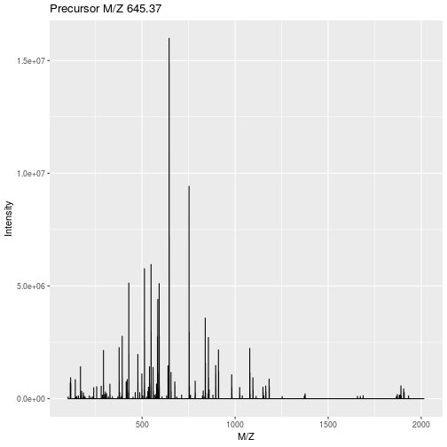

Plotting a object of class `Spectrum`.

```r
plot(msexp[[1]], full=TRUE)
```

As this data was labeled with iTRAQ4 isobaric tags, we can highlight these four peaks of interest with

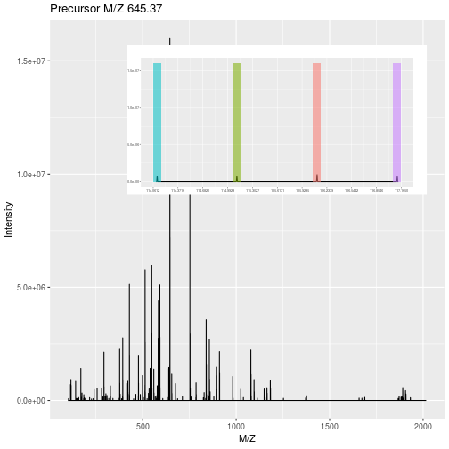

Plotting a object of class `Spectrum` with reporter ions.

```r
plot(msexp[[1]], full=TRUE, reporters = iTRAQ4)
```

```r
msexp[1:3]
```

```
## MSn experiment data ("MSnExp")
## Object size in memory: 0.11 Mb
## - - - Spectra data - - -
##  MS level(s): 2
##  Number of spectra: 3
##  MSn retention times: 25:1 - 25:2 minutes
## - - - Processing information - - -
## Data loaded: Wed Jul 11 08:58:03 2018
## Data [numerically] subsetted 3 spectra: Wed Jul 11 08:58:05 2018
##  MSnbase version: 2.6.1
## - - - Meta data  - - -
## phenoData
##   rowNames: dummyiTRAQ.mzXML
##   varLabels: sampleNames
##   varMetadata: labelDescription
## Loaded from:
##   dummyiTRAQ.mzXML
## protocolData: none
## featureData
##   featureNames: F1.S1 F1.S2 F1.S3
##   fvarLabels: spectrum acquisition.number ... npsm.pep (33 total)
##   fvarMetadata: labelDescription
## experimentData: use 'experimentData(object)'
```

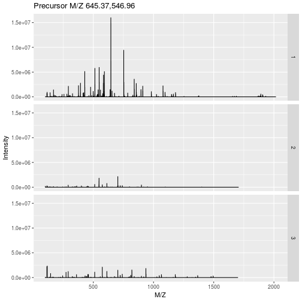

Plotting a object of class `MSnExp`

```r
plot(msexp[1:3], full=TRUE)
```

In the examples ablove, we only used a single file as input to `readMSData`, but multiple file can be read into a single `MSnExp` object. The origin of the spectra can be accessed with the `fromFile` function:

```r
fromFile(msexp)
```

```
## F1.S1 F1.S2 F1.S3 F1.S4 F1.S5
##     1     1     1     1     1
```

> **Exercise** Repeat the previous combination of raw and identification data with the `TMT_Erwinia_1uLSike_Top10HCD_isol2_45stepped_60min_01-20141210.mzML.gz` and `TMT_Erwinia_1uLSike_Top10HCD_isol2_45stepped_60min_01-20141210.mzid` files from `msdata`. Retain only MS level data; this can be done either when reading the data in (see the `msLevel` argument in `?readMSData`) or can be done afterwards by filtering the MS levels with `filterMsLevel`.

```r
## read raw data
rwf <- proteomics(pattern = "TMT_Erwinia_1uLSike_Top10HCD_isol2_45stepped_60min_01-20141210.mzML.gz",
                  full.names = TRUE)
tmterw <- readMSData(rwf, mode = "onDisk")
## or, only read MS2-leve data
## tmterw <- readMSData(rwf, mode = "onDisk", msLevel = 2L)

## add identification data
idf <- ident(full.names = TRUE)
tmterw <- addIdentificationData(tmterw, idf)

tmterw2 <- filterMsLevel(tmterw, 2L)
```

```r
## It is also possible to chain operations
library("magrittr")
tmterw2 <- rwf %>%
    readMSData(mode = "onDisk") %>%
    addIdentificationData(idf) %>%
    filterMsLevel(2L)
```

> **Exercise** Still using the `TMT_Erwinia_1uLSike_Top10HCD_isol2_45stepped_60min_01-20141210` data from the previous exercise, identify the index of the MS2 spectrum with the highest precursor intensity (see the `precursorIntensity` feature variable) and plot it as illustrated above.

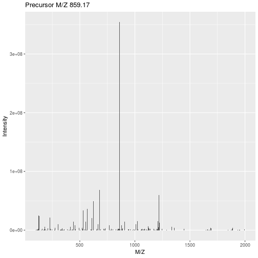

```r
i <- which.max(precursorIntensity(tmterw2))
sp <- tmterw2[[i]]
plot(sp, full = TRUE)
```

## 4.3 Relations between scans

As seen in the introduction, scans have a hierarchical structure: MS2 spectra stem form a precursor MS1 scan. This also holds for MS3 spectra, that are the result from an additional analysis round of MS2 spectra. When validating quantitative or identification data by referring back to raw data, it is often useful to be able to navigate this structure.

We will use an experiment with 3 MS levels to do this:

```r
ms3f <- proteomics(pattern = "MS3TMT11", full.names = TRUE)
basename(ms3f)
```

```
## [1] "MS3TMT11.mzML"
```

```r
ms3 <- readMSData(ms3f, mode = "onDisk")
```

Note that it is important to use *on-disk* mode here, as we want to retain all MS levels, which isn’t possible with *in-memory* mode.

> **Exercise** Compute a table showing how many MS1, 2, and 3 level scans are available in this data

```r
table(msLevel(ms3))
```

```
##
##   1   2   3
##  30 482 482
```

The `filterPrecursorScan` function takes on raw data object, it’s acquisition number (get them with `acquisitionNum`), and returns a new raw data object containing the children of that spectrum.

> **Exercise** Find the acquisition of the first MS1 spectrum and extract all spectra that originate, directly and indirectly, from it.

```r
head(msLevel(ms3))
```

```
## F1.S001 F1.S002 F1.S003 F1.S004 F1.S005 F1.S006
##       1       2       2       3       2       2
```

```r
head(acquisitionNum(ms3))
```

```
## F1.S001 F1.S002 F1.S003 F1.S004 F1.S005 F1.S006
##   21945   21946   21947   21948   21949   21950
```

```r
(from1 <- filterPrecursorScan(ms3, 21945))
```

```
## MSn experiment data ("OnDiskMSnExp")
## Object size in memory: 0.05 Mb
## - - - Spectra data - - -
##  MS level(s): 1 2 3
##  Number of spectra: 35
##  MSn retention times: 45:27 - 45:30 minutes
## - - - Processing information - - -
## Data loaded [Wed Jul 11 08:58:28 2018]
## Filter: select parent/children scans for 21945 [Wed Jul 11 08:58:28 2018]
##  MSnbase version: 2.6.1
## - - - Meta data  - - -
## phenoData
##   rowNames: MS3TMT11.mzML
##   varLabels: sampleNames
##   varMetadata: labelDescription
## Loaded from:
##   MS3TMT11.mzML
## protocolData: none
## featureData
##   featureNames: F1.S001 F1.S002 ... F1.S035 (35 total)
##   fvarLabels: fileIdx spIdx ... spectrum (29 total)
##   fvarMetadata: labelDescription
## experimentData: use 'experimentData(object)'
```

```r
msLevel(from1)
```

```
## F1.S001 F1.S002 F1.S003 F1.S004 F1.S005 F1.S006 F1.S007 F1.S008 F1.S009
##       1       2       2       3       2       2       3       2       2
## F1.S010 F1.S011 F1.S012 F1.S013 F1.S014 F1.S015 F1.S016 F1.S017 F1.S018
##       3       3       2       3       2       2       2       3       2
## F1.S019 F1.S020 F1.S021 F1.S022 F1.S023 F1.S024 F1.S025 F1.S026 F1.S027
##       2       3       2       2       2       3       2       2       3
## F1.S028 F1.S029 F1.S030 F1.S031 F1.S032 F1.S033 F1.S034 F1.S035
##       3       3       3       3       3       3       3       3
```

## 4.4 Low-level access to raw data

Devel

This section illustrates the underlying infrastructure from the `mzR` package, that is used by `MSnbase` under the hood. It is recommended to use the high level interfaces, as it supports multiple files and does data integrity checks throughout data processing.

The `mzR` package provides an interface to the [proteowizard](http://proteowizard.sourceforge.net/) C/C++ code base to access various raw data files, such as `mzML`, `mzXML`, `netCDF`, and `mzData`. The data is accessed on-disk, i.e it is not loaded entirely in memory, and only when explicitly requested. The three main functions are `openMSfile` to create a file handle to a raw data file, `header` to extract metadata about the spectra contained in the file and `peaks` to extract one or multiple spectra of interest. Other functions such as `instrumentInfo`, or `runInfo` can be used to gather general information about a run.

Below, we access the raw data file downloaded in the previous section and open a file handle that will allow us to extract data and metadata of interest.

```r
library("mzR")
basename(mzf)
```

```
## [1] "TMT_Erwinia_1uLSike_Top10HCD_isol2_45stepped_60min_01-20141210.mzML"
```

```r
ms <- openMSfile(mzf)
ms
```

```
## Mass Spectrometry file handle.
## Filename:  TMT_Erwinia_1uLSike_Top10HCD_isol2_45stepped_60min_01-20141210.mzML
## Number of scans:  7534
```

The object loaded from *AnnotationHub* in the previous section is of the same type, and was also created by the `openMSfile` function. All operations below can equally be applied to it.

The `header` function returns the metadata of all available peaks:

```r
hd <- header(ms)
dim(hd)
```

```
## [1] 7534   25
```

```r
names(hd)
```

```
##  [1] "seqNum"                   "acquisitionNum"
##  [3] "msLevel"                  "polarity"
##  [5] "peaksCount"               "totIonCurrent"
##  [7] "retentionTime"            "basePeakMZ"
##  [9] "basePeakIntensity"        "collisionEnergy"
## [11] "ionisationEnergy"         "lowMZ"
## [13] "highMZ"                   "precursorScanNum"
## [15] "precursorMZ"              "precursorCharge"
## [17] "precursorIntensity"       "mergedScan"
## [19] "mergedResultScanNum"      "mergedResultStartScanNum"
## [21] "mergedResultEndScanNum"   "injectionTime"
## [23] "filterString"             "spectrumId"
## [25] "centroided"
```

We can extract metadata and scan data for scan 1000 as follows:

```r
hd[1000, ]
```

```
##      seqNum acquisitionNum msLevel polarity peaksCount totIonCurrent
## 1000   1000           1000       2        1        274       1048554
##      retentionTime basePeakMZ basePeakIntensity collisionEnergy
## 1000      1106.916    136.061            164464              45
##      ionisationEnergy    lowMZ   highMZ precursorScanNum precursorMZ
## 1000                0 104.5467 1370.758              992    683.0817
##      precursorCharge precursorIntensity mergedScan mergedResultScanNum
## 1000               2           689443.7          0                   0
##      mergedResultStartScanNum mergedResultEndScanNum injectionTime
## 1000                        0                      0      55.21463
##                                                  filterString
## 1000 FTMS + p NSI d Full ms2 683.08@hcd45.00 [100.00-1380.00]
##                                         spectrumId centroided
## 1000 controllerType=0 controllerNumber=1 scan=1000       TRUE
```

```r
head(peaks(ms, 1000))
```

```
##          [,1]     [,2]
## [1,] 104.5467 308.9326
## [2,] 104.5684 308.6961
## [3,] 108.8340 346.7183
## [4,] 109.3928 365.1236
## [5,] 110.0345 616.7905
## [6,] 110.0703 429.1975
```

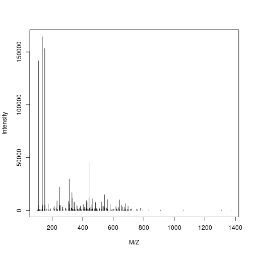

Manual extraction and plotting of an MS spectrum

```r
plot(peaks(ms, 1000), type = "h", xlab = "M/Z", ylab = "Intensity")
```

See also this short [video](https://youtu.be/KwCRV885Z-k).

## 4.5 A bit more raw data visualisation

```r
## (1) MS space heaptmap
M <- MSmap(ms, ms1[rtsel], 521, 523, .005, hd)
```

[output not shown]

```r
ff <- colorRampPalette(c("yellow", "steelblue"))
trellis.par.set(regions=list(col=ff(100)))
m1 <- plot(M, aspect = 1, allTicks = FALSE)
```

[output not shown]

```r
## (2) Same data as (1), in 3 dimenstion
M@map[msMap(M) == 0] <- NA
```

[output not shown]

```r
m2 <- plot3D(M, rgl = FALSE)
```

[output not shown]

```r
## (3) The 2 MS1 and 10 interleaved MS2 spectra from above
i <- ms1[which(rtsel)][1]
```

[output not shown]

```r
j <- ms1[which(rtsel)][2]
```

[output not shown]

```r
M2 <- MSmap(ms, i:j, 100, 1000, 1, hd)
```

[output not shown]

```r
m3 <- plot3D(M2)
```

[output not shown]

```r
grid.arrange(m1, m2, m3, ncol = 3)
```

[output not shown]

Below, we have animations build from extracting successive slices as above.

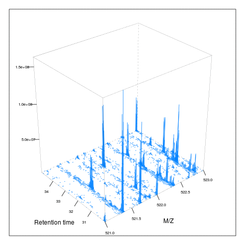

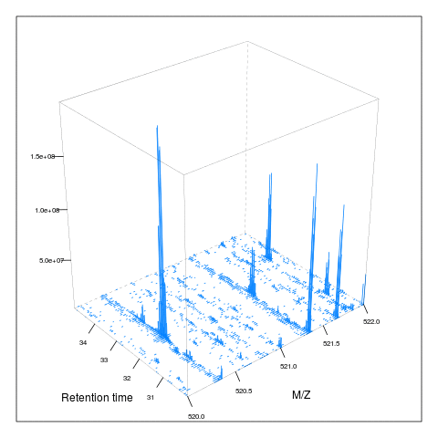

# 5 Identification data

## 5.1 Identification data.frame

Let’s use the identification from from `msdata`:

```r
idf <- msdata::ident(full.names = TRUE)
basename(idf)
```

```
## [1] "TMT_Erwinia_1uLSike_Top10HCD_isol2_45stepped_60min_01-20141210.mzid"
```

The easiest way to read identification data in `mzIdentML` (often abbreviated with `mzid`) into R is to read it with `readMzIdData`, that will parse it, process it, and return a `data.frame`:

```r
iddf <- readMzIdData(idf)
head(iddf)
```

```
##                    sequence                                    spectrumID
## 1              RQCRTDFLNYLR controllerType=0 controllerNumber=1 scan=2949
## 2    ESVALADQVTCVDWRNRKATKK controllerType=0 controllerNumber=1 scan=6534
## 3              KELLCLAMQIIR controllerType=0 controllerNumber=1 scan=5674
##   chargeState rank passThreshold experimentalMassToCharge
## 1           3    1          TRUE                 548.2856
## 2           2    1          TRUE                1288.1528
## 3           2    1          TRUE                 744.4109
##   calculatedMassToCharge modNum isDecoy post pre start end DatabaseAccess
## 1               547.9474      1   FALSE    V   R   574 585        ECA2006
## 2              1288.1741      1   FALSE    G   R    69  90        ECA1676
## 3               744.4255      1    TRUE    Q   R   131 142    XXX_ECA2855
##   DBseqLength DatabaseSeq
## 1        1295
## 2         110
```

[output cut: 30 more lines]

When adding identification data with the `addIdentificationData` function as shown above, the data is first read with `readMzIdData`, and is then cleaned up:

- only PSMs matching the regular (non-decoy) database are retained;
- PSMs or rank greater than 1 are discarded;
- only proteotypic peptides are kept, i.e. those that match to a unique peptide.

```r
## at this stage, we still have all the PSMs
table(iddf$isDecoy)
```

```
##
## FALSE  TRUE
##  2906  2896
```

```r
table(iddf$rank)
```

```
##
##    1    2    3    4
## 5487  302   12    1
```

> **Exercise** This behaviour can be replicates with the `filterIdentificationDataFrame` function. Try it out for yourself.

```r
iddf2 <- filterIdentificationDataFrame(iddf)
table(iddf2$isDecoy)
```

```
##
## FALSE
##  2710
```

```r
table(iddf2$rank)
```

```
##
##    1
## 2710
```

> **Exercise** Data wrangling with identification data; the standard *tidyverse* tools are fit for purpose here. Extract and combine the PSMs and their scores as described above and combine them. From the available data, calculate the length of each peptide (you can use `nchar` with the peptide sequence `sequence`) and the number of peptides for each protein (`DatabaseDescription`). Plot the length of the proteins for their respective number of peptides. Optionally, stratify the plot by the peptide e-value score (`MS.GF.EValue`) using for example `cut` to define bins.

```r
suppressPackageStartupMessages(library("dplyr"))
iddf2 <- as_tibble(iddf2) %>%
    mutate(peplen = nchar(sequence))
npeps <- iddf2 %>%
    group_by(DatabaseDescription) %>%
    tally
iddf2 <- full_join(iddf2, npeps)
```

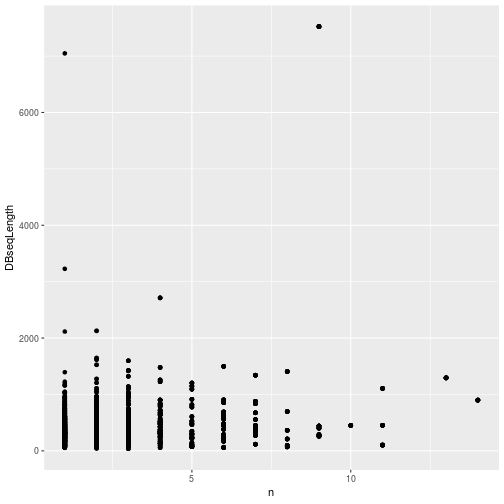

Identifcation data wrangling 1

```r
library("ggplot2")
ggplot(iddf2, aes(x = n, y = DBseqLength)) + geom_point()
```

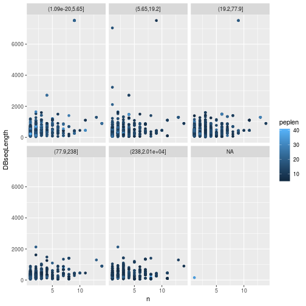

```r
iddf2$evalBins <- cut(iddf2$MS.GF.EValue, summary(iddf2$MS.GF.EValue))
ggplot(iddf2, aes(x = n, y = DBseqLength, color = peplen)) +
    geom_point() +
    facet_wrap(~ evalBins)
```

## 5.2 Low level access to id data

Devel

Along the lines of what is available for raw data, the parsing of this XML-based format comes from `mzR`. A file handle to `mzIdentML` files can be created with the `openIDfile` function. As for raw data, the underlying C/C++ code comes from the [proteowizard](http://proteowizard.sourceforge.net/).

```r
library("mzR")
id1 <- openIDfile(idf)
id1
```

```
## Identification file handle.
## Filename:  TMT_Erwinia_1uLSike_Top10HCD_isol2_45stepped_60min_01-20141210.mzid
## Number of psms:  5759
```

Various data can be extracted from the identification object. The peptide spectrum matches (PSMs) and the identification scores can be accessed as a data.frame with `psms` and `score` respectively.

```r
softwareInfo(id1)
```

```
## [1] "MS-GF+ Beta (v10072) "
## [2] "ProteoWizard MzIdentML 3.0.501 ProteoWizard"
```

```r
enzymes(id1)
```

```
##      name nTermGain cTermGain minDistance missedCleavages
## 1 Trypsin                               0            1000
```

```r
fid1 <- mzR::psms(id1)
head(fid1)
```

```
##                                      spectrumID chargeState rank
## 1 controllerType=0 controllerNumber=1 scan=5782           3    1
## 2 controllerType=0 controllerNumber=1 scan=6037           3    1
## 3 controllerType=0 controllerNumber=1 scan=5235           3    1
## 4 controllerType=0 controllerNumber=1 scan=5397           3    1
## 5 controllerType=0 controllerNumber=1 scan=6075           3    1
##   passThreshold experimentalMassToCharge calculatedMassToCharge
## 1          TRUE                1080.2325              1080.2321
## 2          TRUE                1002.2089              1002.2115
## 3          TRUE                1189.2836              1189.2800
## 4          TRUE                 960.5365               960.5365
## 5          TRUE                1264.3409              1264.3419
##                              sequence modNum isDecoy post pre start end
## 1 PVQIQAGEDSNVIGALGGAVLGGFLGNTIGGGSGR      0   FALSE    S   R    50  84
## 2        TQVLDGLINANDIEVPVALIDGEIDVLR      0   FALSE    R   K   288 315
```

[output cut: 16 more lines]

```r
sc1 <- mzR::score(id1)
head(sc1)
```

```
##                                      spectrumID MS.GF.RawScore
## 1 controllerType=0 controllerNumber=1 scan=5782            147
## 2 controllerType=0 controllerNumber=1 scan=6037            214
## 3 controllerType=0 controllerNumber=1 scan=5235            211
## 4 controllerType=0 controllerNumber=1 scan=5397            154
## 5 controllerType=0 controllerNumber=1 scan=6075            188
## 6 controllerType=0 controllerNumber=1 scan=5761            123
##   MS.GF.DeNovoScore MS.GF.SpecEValue MS.GF.EValue MS.GF.QValue
## 1               174     3.764831e-27 1.086033e-20            0
## 2               245     6.902626e-26 1.988774e-19            0
## 3               264     1.778789e-25 5.129649e-19            0
## 4               178     1.792541e-24 5.163566e-18            0
## 5               252     1.510364e-23 4.356914e-17            0
## 6               138     1.618941e-23 4.658952e-17            0
##   MS.GF.PepQValue
## 1               0
## 2               0
## 3               0
## 4               0
## 5               0
## 6               0
```

The *mzID* package, has similar functionality to parse identification files, and was the first one to provide such capabilities in R. The main difference with *mzR* is that is parses the files using the *XML*package and reads the whole data into memory rather than relying on proteowizard, and is slower.

## 5.3 MS/MS database search

While searches are generally performed using third-party software independently of R or can be started from R using a `system` call, the *MSGFplus* package enables to perform a search using the MSGF+ engine, as illustrated below.

We search the TMT_Erwinia_1uLSike_Top10HCD_isol2_45stepped_60min_01-20141210.mzML file against the fasta file from `PXD000001` using `MSGFplus`.

We first download the fasta files from ProteomeXchange

On-line

```r
fas <- pxget(px, "erwinia_carotovora.fasta")
basename(fas)
```

```
## [1] "erwinia_carotovora.fasta"
```

Below, we setup and run the search.

In the `runMSGF` call, the memory allocated to the java virtual machine is limited to 1GB. In general, there is no need to specify this argument, unless you experience an error regarding the *maximum heap size*.

```r
library("MSGFplus")
msgfpar <- msgfPar(database = fas,
                   instrument = 'HighRes',
                   tda = TRUE,
                   enzyme = 'Trypsin',
                   protocol = 'iTRAQ')
idres <- runMSGF(msgfpar, mzf, memory=1000)
```

```
## '/usr/bin/java' -Xmx1000M -jar '/home/lg390/R/x86_64-pc-linux-gnu-library/3.4/MSGFplus/MSGFPlus/MSGFPlus.jar' -s '/home/lg390/Documents/Teaching/bioc-ms-prot/TMT_Erwinia_1uLSike_Top10HCD_isol2_45stepped_60min_01-20141210.mzML' -o '/home/lg390/Documents/Teaching/bioc-ms-prot/TMT_Erwinia_1uLSike_To…
##
## reading TMT_Erwinia_1uLSike_Top10HCD_isol2_45stepped_60min_01-20141210.mzid... DONE!
```

```r
idres
```

```
## An mzID object
##
## Software used:   MS-GF+ (version: Beta (v10072))
##
## Rawfile:         /home/lg390/Documents/Teaching/bioc-ms-prot/TMT_Erwinia_1uLSike_Top10HCD_isol2_45stepped_60min_01-20141210.mzML
##
## Database:        /home/lg390/Documents/Teaching/bioc-ms-prot/erwinia_carotovora.fasta
##
## Number of scans: 5343
## Number of PSM's: 5656
```

```r
## identification file (needed below)
basename(mzID::files(idres)$id)
```

```
## [1] "TMT_Erwinia_1uLSike_Top10HCD_isol2_45stepped_60min_01-20141210.mzid"
```

A graphical interface to perform the search the data and explore the results is also available:

```r
library("MSGFgui")
MSGFgui()
```

[figure not shown]

The *MSGFgui* interface

The *rTANDEM* package can be used to perform a search with *XTandem* software.

## 5.4 Analysing search results

The *MSnID* package can be used for post-search filtering of MS/MS identifications. One starts with the construction of an `MSnID` object that is populated with identification results that can be imported from a `data.frame` or from `mzIdenML` files. Here, we will use the example identification data provided with the package.

```r
mzids <- system.file("extdata", "c_elegans.mzid.gz", package="MSnID")
basename(mzids)
```

```
## [1] "c_elegans.mzid.gz"
```

We start by loading the package, initialising the `MSnID` object, and add the identification result from our `mzid` file (there could of course be more that one).

```r
library("MSnID")
msnid <- MSnID(".")
```

```
## Note, the anticipated/suggested columns in the
## peptide-to-spectrum matching results are:
## -----------------------------------------------
## accession
## calculatedMassToCharge
## chargeState
## experimentalMassToCharge
## isDecoy
## peptide
## spectrumFile
## spectrumID
```

```r
msnid <- read_mzIDs(msnid, mzids)
```

```
## Loaded cached data
```

```r
show(msnid)
```

```
## MSnID object
## Working directory: "."
## #Spectrum Files:  1
## #PSMs: 12263 at 36 % FDR
## #peptides: 9489 at 44 % FDR
## #accessions: 7414 at 76 % FDR
```

Printing the `MSnID` object returns some basic information such as

- Working directory.
- Number of spectrum files used to generate data.
- Number of peptide-to-spectrum matches and corresponding FDR.
- Number of unique peptide sequences and corresponding FDR.
- Number of unique proteins or amino acid sequence accessions and corresponding FDR.

The package then enables to define, optimise and apply filtering based for example on missed cleavages, identification scores, precursor mass errors, etc. and assess PSM, peptide and protein FDR levels. To properly function, it expects to have access to the following data

```
## [1] "accession"                "calculatedMassToCharge"
## [3] "chargeState"              "experimentalMassToCharge"
## [5] "isDecoy"                  "peptide"
## [7] "spectrumFile"             "spectrumID"
```

which are indeed present in our data:

```r
names(msnid)
```

```
##  [1] "spectrumID"                "scan number(s)"
##  [3] "acquisitionNum"            "passThreshold"
##  [5] "rank"                      "calculatedMassToCharge"
##  [7] "experimentalMassToCharge"  "chargeState"
##  [9] "MS-GF:DeNovoScore"         "MS-GF:EValue"
## [11] "MS-GF:PepQValue"           "MS-GF:QValue"
## [13] "MS-GF:RawScore"            "MS-GF:SpecEValue"
## [15] "AssumedDissociationMethod" "IsotopeError"
## [17] "isDecoy"                   "post"
## [19] "pre"                       "end"
## [21] "start"                     "accession"
## [23] "length"                    "description"
## [25] "pepSeq"                    "modified"
## [27] "modification"              "idFile"
## [29] "spectrumFile"              "databaseFile"
## [31] "peptide"
```

Here, we summarise a few steps and redirect the reader to the package’s vignette for more details:

### Analysis of peptide sequences

Cleaning irregular cleavages at the termini of the peptides and missing cleavage site within the peptide sequences. The following two function call create the new `numMisCleavages` and `numIrrCleabages` columns in the `MSnID` object

```r
msnid <- assess_termini(msnid, validCleavagePattern="[KR]\\.[^P]")
msnid <- assess_missed_cleavages(msnid, missedCleavagePattern="[KR](?=[^P$])")
```

### Trimming the data

Now, we can use the `apply_filter` function to effectively apply filters. The strings passed to the function represent expressions that will be evaluated, this keeping only PSMs that have 0 irregular cleavages and 2 or less missed cleavages.

```r
msnid <- apply_filter(msnid, "numIrregCleavages == 0")
msnid <- apply_filter(msnid, "numMissCleavages <= 2")
show(msnid)
```

```
## MSnID object
## Working directory: "."
## #Spectrum Files:  1
## #PSMs: 7838 at 17 % FDR
## #peptides: 5598 at 23 % FDR
## #accessions: 3759 at 53 % FDR
```

### Parent ion mass errors

Using `"calculatedMassToCharge"` and `"experimentalMassToCharge"`, the `mass_measurement_error` function calculates the parent ion mass measurement error in parts per million.

```r
summary(mass_measurement_error(msnid))
```

```
##       Min.    1st Qu.     Median       Mean    3rd Qu.       Max.
## -2184.0640    -0.6992     0.0000    17.6146     0.7512  2012.5178
```

We then filter any matches that do not fit the +/- 20 ppm tolerance

```r
msnid <- apply_filter(msnid, "abs(mass_measurement_error(msnid)) < 20")
summary(mass_measurement_error(msnid))
```

```
##     Min.  1st Qu.   Median     Mean  3rd Qu.     Max.
## -19.7797  -0.5866   0.0000  -0.2970   0.5713  19.6758
```

### Filtering criteria

Filtering of the identification data will rely on

- -log10 transformed MS-GF+ Spectrum E-value, reflecting the goodness of match experimental and theoretical fragmentation patterns

```r
msnid$msmsScore <- -log10(msnid$`MS-GF:SpecEValue`)
```

- the absolute mass measurement error (in ppm units) of the parent ion

```r
msnid$absParentMassErrorPPM <- abs(mass_measurement_error(msnid))
```

MS2 filters are handled by a special `MSnIDFilter` class objects, where individual filters are set by name (that is present in `names(msnid)`) and comparison operator (>, <, = , …) defining if we should retain hits with higher or lower given the threshold and finally the threshold value itself.

```r
filtObj <- MSnIDFilter(msnid)
filtObj$absParentMassErrorPPM <- list(comparison="<", threshold=10.0)
filtObj$msmsScore <- list(comparison=">", threshold=10.0)
show(filtObj)
```

```
## MSnIDFilter object
## (absParentMassErrorPPM < 10) & (msmsScore > 10)
```

We can then evaluate the filter on the identification data object, which return the false discovery rate and number of retained identifications for the filtering criteria at hand.

```r
evaluate_filter(msnid, filtObj)
```

```
##           fdr    n
## PSM         0 3807
## peptide     0 2455
## accession   0 1009
```

### Filter optimisation

Rather than setting filtering values by hand, as shown above, these can be set automativally to meet a specific false discovery rate.

```r
filtObj.grid <- optimize_filter(filtObj, msnid, fdr.max=0.01,
                                method="Grid", level="peptide",
                                n.iter=500)
show(filtObj.grid)
```

```
## MSnIDFilter object
## (absParentMassErrorPPM < 3) & (msmsScore > 7.4)
```

```r
evaluate_filter(msnid, filtObj.grid)
```

```
##                   fdr    n
## PSM       0.004097561 5146
## peptide   0.006447651 3278
## accession 0.021996616 1208
```

Filters can eventually be applied (rather than just evaluated) using the `apply_filter` function.

```r
msnid <- apply_filter(msnid, filtObj.grid)
show(msnid)
```

```
## MSnID object
## Working directory: "."
## #Spectrum Files:  1
## #PSMs: 5146 at 0.41 % FDR
## #peptides: 3278 at 0.64 % FDR
## #accessions: 1208 at 2.2 % FDR
```

And finally, identifications that matched decoy and contaminant protein sequences are removed

```r
msnid <- apply_filter(msnid, "isDecoy == FALSE")
msnid <- apply_filter(msnid, "!grepl('Contaminant',accession)")
show(msnid)
```

```
## MSnID object
## Working directory: "."
## #Spectrum Files:  1
## #PSMs: 5117 at 0 % FDR
## #peptides: 3251 at 0 % FDR
## #accessions: 1179 at 0 % FDR
```

The resulting filtered identification data can be exported to a `data.frame` or to a dedicated `MSnSet` data structure for quantitative MS data, described below, and further processed and analyses using appropriate statistical tests.

## 5.5 Visualising identification data

Annotated spectra and comparing spectra.

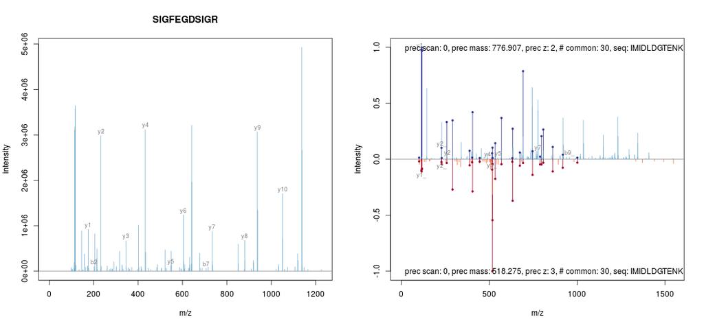

Annotating and comparing MS2 spectra.

```r
par(mfrow = c(1, 2))
data(itraqdata)
itraqdata2 <- pickPeaks(itraqdata, verbose = FALSE) ## centroiding
s <- "SIGFEGDSIGR"
plot(itraqdata2[[14]], s, main = s)
plot(itraqdata2[[25]], itraqdata2[[28]], sequences = rep("IMIDLDGTENK", 2))
```

The annotation of spectra is obtained by simulating fragmentation of a peptide and matching observed peaks to fragments:

```r
calculateFragments("SIGFEGDSIGR")
```

```
##            mz  ion type pos z        seq
## 1    88.03931   b1    b   1 1          S
## 2   201.12337   b2    b   2 1         SI
## 3   258.14483   b3    b   3 1        SIG
## 4   405.21324   b4    b   4 1       SIGF
## 5   534.25583   b5    b   5 1      SIGFE
## 6   591.27729   b6    b   6 1     SIGFEG
## 7   706.30423   b7    b   7 1    SIGFEGD
## 8   793.33626   b8    b   8 1   SIGFEGDS
## 9   906.42032   b9    b   9 1  SIGFEGDSI
## 10  963.44178  b10    b  10 1 SIGFEGDSIG
## 11  175.11895   y1    y   1 1          R
## 12  232.14041   y2    y   2 1         GR
## 13  345.22447   y3    y   3 1        IGR
## 14  432.25650   y4    y   4 1       SIGR
## 15  547.28344   y5    y   5 1      DSIGR
## 16  604.30490   y6    y   6 1     GDSIGR
##  [ reached getOption("max.print") -- omitted 16 rows ]
```

# 6 Quantitative proteomics

There are a wide range of proteomics quantitation techniques that can broadly be classified as labelled vs. label-free, depending whether the features are labelled prior the MS acquisition and the MS level at which quantitation is inferred, namely MS1 or MS2.

|  | Label-free | Labelled |
| --- | --- | --- |
| MS1 | XIC | SILAC, 15N |
| MS2 | Counting | iTRAQ, TMT |

In terms of raw data quantitation, most efforts have been devoted to MS2-level quantitation. Label-free XIC quantitation has however been addressed in the frame of metabolomics data processing by the *xcms* infrastructure.

Below is a list of suggested packages for some common proteomics quantitation technologies:

- Isobaric tagging (iTRAQ and TMT): *MSnbase* and *isobar*.
- Label-free: *xcms* (metabolomics).
- Counting: *MSnbase* and *MSnID* for peptide-spectrum matching confidence assessment.
- *N14N15* for heavy Nitrogen-labelled data.

## 6.1 Isobaric tagging

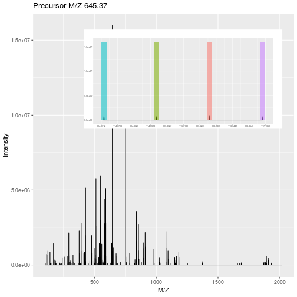

MS2 spectrum and it’s iTRAQ4 reporter ions.

```r
plot(msexp[[1]], full=TRUE, reporters = iTRAQ4)
```

```r
msset <- quantify(msexp, method = "max", reporters = iTRAQ4)
```

New columns can be added to the metadata slots.

```r
exprs(msset)
```

```
##       iTRAQ4.114 iTRAQ4.115 iTRAQ4.116 iTRAQ4.117
## F1.S1   706555.7   685055.1   929016.1   668245.2
## F1.S2   260663.7   212745.0   163782.8   239142.7
## F1.S3  2213566.0  2069209.6  2204032.2  2331846.8
## F1.S4   616043.4   705976.6   671828.8   666845.6
## F1.S5  1736128.2  1787622.5  1795311.8  1825523.0
```

```r
pData(msset)
```

```
##                  mz reporters
## iTRAQ4.114 114.1112    iTRAQ4
## iTRAQ4.115 115.1083    iTRAQ4
## iTRAQ4.116 116.1116    iTRAQ4
## iTRAQ4.117 117.1150    iTRAQ4
```

```r
pData(msset)$groups <- rep(c("Treat", "Cond"), each = 2)
pData(msset)
```

```
##                  mz reporters groups
## iTRAQ4.114 114.1112    iTRAQ4  Treat
## iTRAQ4.115 115.1083    iTRAQ4  Treat
## iTRAQ4.116 116.1116    iTRAQ4   Cond
## iTRAQ4.117 117.1150    iTRAQ4   Cond
```

Another useful slot is `processingData`, accessed with `processingData(.)`, that records all the processing that objects have undergone since their creation.

```r
processingData(msset)
```

```
## - - - Processing information - - -
## Data loaded: Wed Jul 11 08:58:03 2018
## iTRAQ4 quantification by max: Wed Jul 11 08:58:35 2018
##  MSnbase version: 2.6.1
```

**See also** The *isobar* package supports quantitation from centroided `mgf` peak lists or its own tab-separated files that can be generated from Mascot and Phenyx vendor files.

## 6.2 Spectral counting

Other MS2 quantitation methods available in `quantify` include the (normalised) spectral index `SI` and (normalised) spectral abundance factor `SAF` or simply a simple count method.

The code below is for illustration only - it doesn’t make much sense to perform any of these quantitations on such a multiplexed data

```r
exprs(si <- quantify(msexp, method = "SIn"))
```

```
##         dummyiTRAQ.mzXML
## ECA0510     0.0006553518
## ECA0984     0.0035384487
## ECA1028     0.0002684726
```

```r
exprs(saf <- quantify(msexp, method = "NSAF"))
```

```
##         dummyiTRAQ.mzXML
## ECA0510        0.4306167
## ECA0984        0.3094475
## ECA1028        0.2599359
```

Note that spectra that have not been assigned any peptide (`NA`) or that match non-unique peptides (`npsm > 1`) are discarded in the counting process.

As shown above, the *MSnID* package enables to explore and assess the confidence of identification data using `mzid` files. A subset of all peptide-spectrum matches, that pass a specific false discovery rate threshold can them be converted to an `MSnSet`, where the number of peptide occurrences are used to populate the assay data.

## 6.3 Importing third-party quantitation data

### From `MzTab` files

On-line

The Proteomics Standard Initiative (PSI) `mzTab` file format is aimed at providing a simpler (than XML formats) and more accessible file format to the wider community. It is composed of a key-value metadata section and peptide/protein/small molecule tabular sections. These data can be imported with the `readMzTabData` function.

We specify version 0.9 (which generates the warning) to fit with the version of that file. For recent files, the `version` argument should be ignored to use the importer for the current file version 1.0.

```r
mztf <- pxget(px, "F063721.dat-mztab.txt")
(mzt <- readMzTabData(mztf, what = "PEP", version = "0.9"))
```

```
## Warning: Version 0.9 is deprecated. Please see '?readMzTabData' and '?
## MzTab' for details.
```

```
## MSnSet (storageMode: lockedEnvironment)
## assayData: 1528 features, 6 samples
##   element names: exprs
## protocolData: none
## phenoData
##   sampleNames: sub[1] sub[2] ... sub[6] (6 total)
##   varLabels: abundance
##   varMetadata: labelDescription
## featureData
##   featureNames: 1 2 ... 1528 (1528 total)
##   fvarLabels: sequence accession ... uri (14 total)
##   fvarMetadata: labelDescription
## experimentData: use 'experimentData(object)'
## Annotation:
## - - - Processing information - - -
## mzTab read: Mon Jun 19 23:10:32 2017
##  MSnbase version: 2.3.6
```

### From spreadsheets

It is also possible to import arbitrary spreadsheets (such as those exported by MaxQuant, ProteomeDiscoverer, …) as `MSnSet` objects into R with the `readMSnSet2` function. The main 2 arguments of the function are (1) a text-based spreadsheet and (2) column names of indices that identify the quantitation data. The latter can be queried with the `getEcols` function.

```r
csv <- dir(system.file ("extdata" , package = "pRolocdata"),
           full.names = TRUE, pattern = "pr800866n_si_004-rep1.csv")
getEcols(csv, split = ",")
```

```
##  [1] "\"Protein ID\""              "\"FBgn\""
##  [3] "\"Flybase Symbol\""          "\"No. peptide IDs\""
##  [5] "\"Mascot score\""            "\"No. peptides quantified\""
##  [7] "\"area 114\""                "\"area 115\""
##  [9] "\"area 116\""                "\"area 117\""
## [11] "\"PLS-DA classification\""   "\"Peptide sequence\""
## [13] "\"Precursor ion mass\""      "\"Precursor ion charge\""
## [15] "\"pd.2013\""                 "\"pd.markers\""
```

```r
ecols <- 7:10
res <- readMSnSet2(csv, ecols)
head(exprs(res))
```

```
##   area.114 area.115 area.116 area.117
## 1 0.379000 0.281000 0.225000 0.114000
## 2 0.420000 0.209667 0.206111 0.163889
## 3 0.187333 0.167333 0.169667 0.476000
## 4 0.247500 0.253000 0.320000 0.179000
## 5 0.216000 0.183000 0.342000 0.259000
## 6 0.072000 0.212333 0.573000 0.142667
```

```r
head(fData(res))
```

```
##   Protein.ID        FBgn Flybase.Symbol No..peptide.IDs Mascot.score
## 1    CG10060 FBgn0001104    G-ialpha65A               3       179.86
## 2    CG10067 FBgn0000044         Act57B               5       222.40
## 3    CG10077 FBgn0035720        CG10077               5       219.65
## 4    CG10079 FBgn0003731           Egfr               2        86.39
## 5    CG10106 FBgn0029506        Tsp42Ee               1        52.10
## 6    CG10130 FBgn0010638      Sec61beta               2        79.90
##   No..peptides.quantified PLS.DA.classification Peptide.sequence
## 1                       1                    PM
## 2                       9                    PM
## 3                       3
## 4                       2                    PM
## 5                       1                              GGVFDTIQK
## 6                       3              ER/Golgi
##   Precursor.ion.mass Precursor.ion.charge     pd.2013 pd.markers
## 1                                                  PM    unknown
## 2                                                  PM    unknown
## 3                                             unknown    unknown
## 4                                                  PM    unknown
## 5            626.887                    2 Phenotype 1    unknown
## 6                                            ER/Golgi         ER
```

> **Exercise** Using `readMSnSet2`, load the following file that was part of the supplementary information of a manuscript.

```r
csvfile <- dir(system.file("extdata", package = "pRolocdata"),
               pattern = "hyperLOPIT-SIData-ms3-rep12-intersect.csv",
               full.names = TRUE)
basename(csvfile)
```

```
## [1] "hyperLOPIT-SIData-ms3-rep12-intersect.csv.gz"
```

> You’ll first need to identify which columns to use as expression data. In this case however, two rows are used as header, and you’ll need to set `n` in `getEcols` to retrieve the appropriate one. There are 20 expresion columns annotated as TMT 10 plex reporter ion M/Z values (if you don’t know these, you can find them out by looking at the `TMT10` reporter ion object). You can now use `readMSnSet2`, remembering to skip 1 line and, optionally, use the first column as feature names (see the `fnames` argument). What are the number of features and samples in the data?

```r
getEcols(csvfile, split = ",", n = 2)
```

```
##  [1] ""
##  [2] ""
##  [3] ""
##  [4] "Experiment 1"
##  [5] "Experiment 2"
##  [6] "Experiment 1"
##  [7] "Experiment 2"
##  [8] "126"
##  [9] "127N"
## [10] "127C"
## [11] "128N"
## [12] "128C"
## [13] "129N"
## [14] "129C"
## [15] "130N"
```

[output cut: 30 more lines]

```r
hl <- readMSnSet2(csvfile, ecol = 8:27, fnames = 1, skip = 1)
him(hl)
```

[output not shown]

# 7 Data processing and analysis

## 7.1 Raw data processing

For raw data processing look at `MSnbase`’s `clean`, `smooth`, `pickPeaks`, `removePeaks` and `trimMz` for `MSnExp` and spectra processing methods.

As an illustration, we show the `pickPeaks` function on the `itraqdata` data. Centoiding transforms the distribution of M/Z values measured for an ion (i.e. a set of M/Z and intensities, first figure below) into a single M/Z and intensity pair of values (second figure below).

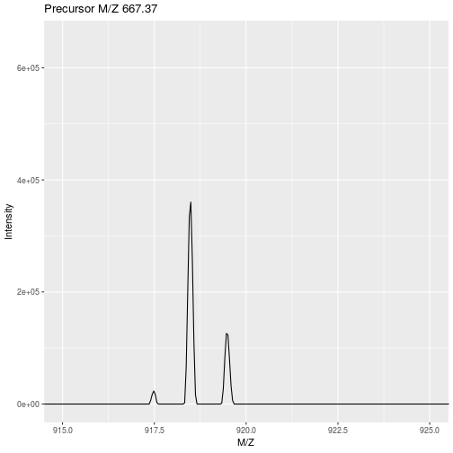

Peak picking: profile mode.

```r
library("ggplot2") ## for coord_cartesian
data(itraqdata)
plot(itraqdata[[10]], full = TRUE) +
    coord_cartesian(xlim = c(915, 925))
```

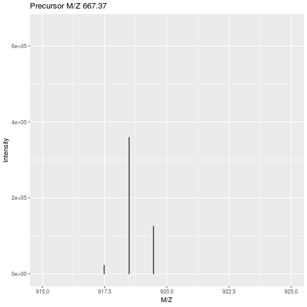

Peak picking: centroided.

```r
itraqdata2 <- pickPeaks(itraqdata)
plot(itraqdata2[[10]], full = TRUE, w1 = 0.05) +
    coord_cartesian(xlim = c(915, 925))
```

The *MALDIquant* and *xcms* packages also features a wide range of raw data processing methods on their own ad hoc data instance types.

## 7.2 Processing and normalisation

Each different types of quantitative data will require their own pre-processing and normalisation steps. Both `isobar` and `MSnbase` allow to correct for isobaric tag impurities normalise the quantitative data.

```r
data(itraqdata)
qnt <- quantify(itraqdata, method = "trap", reporters = iTRAQ4)
impurities <- matrix(c(0.929, 0.059, 0.002, 0.000,
                       0.020, 0.923, 0.056, 0.001,
                       0.000, 0.030, 0.924, 0.045,
                       0.000, 0.001, 0.040, 0.923),
                     nrow = 4, byrow = TRUE)
## or, using makeImpuritiesMatrix()
## impurities <- makeImpuritiesMatrix(4)
qnt <- purityCorrect(qnt, impurities)
processingData(qnt)
```

```
## - - - Processing information - - -
## Data loaded: Wed May 11 18:54:39 2011
## Updated from version 0.3.0 to 0.3.1 [Fri Jul  8 20:23:25 2016]
## iTRAQ4 quantification by trapezoidation: Wed Jul 11 08:58:37 2018
## Purity corrected: Wed Jul 11 08:58:38 2018
##  MSnbase version: 1.1.22
```

Various normalisation methods can be applied the `MSnSet` instances using the `normalise` method: variance stabilisation (`vsn`), quantile (`quantiles`), median or mean centring (`center.media` or `center.mean`), …

```r
qnt <- normalise(qnt, "quantiles")
processingData(qnt)
```

```
## - - - Processing information - - -
## Data loaded: Wed May 11 18:54:39 2011
## Updated from version 0.3.0 to 0.3.1 [Fri Jul  8 20:23:25 2016]
## iTRAQ4 quantification by trapezoidation: Wed Jul 11 08:58:37 2018
## Purity corrected: Wed Jul 11 08:58:38 2018
## Normalised (quantiles): Wed Jul 11 08:58:38 2018
##  MSnbase version: 1.1.22
```

The `combineFeatures` method combines spectra/peptides quantitation values into protein data. The grouping is defined by the `groupBy` parameter, which is generally taken from the feature metadata (protein accessions, for example).

```r
gb <- fData(qnt)$ProteinDescription
prt <- combineFeatures(qnt, groupBy = gb, fun = "median")
```

```
## Your data contains missing values. Please read the relevant
## section in the combineFeatures manual page for details the effects
## of missing values on data aggregation.
```

```r
processingData(prt)
```

```
## - - - Processing information - - -
## Data loaded: Wed May 11 18:54:39 2011
## Updated from version 0.3.0 to 0.3.1 [Fri Jul  8 20:23:25 2016]
## iTRAQ4 quantification by trapezoidation: Wed Jul 11 08:58:37 2018
## Purity corrected: Wed Jul 11 08:58:38 2018
## Normalised (quantiles): Wed Jul 11 08:58:38 2018
## Combined 55 features into 39 using median: Wed Jul 11 08:58:38 2018
##  MSnbase version: 2.6.1
```

### Missing values

Finally, proteomics data analysis is generally hampered by missing values. Missing data imputation is a sensitive operation whose success will be guided by many factors, such as degree and (non-)random nature of the missingness.

Below, we load an `MSnSet` with missing values, count the number missing and non-missing values.

```r
data(naset)
table(is.na(naset))
```

```
##
## FALSE  TRUE
## 10254   770
```

The `naplot` figure will reorder cells within the data matrix so that the experiments and features with many missing values will be grouped towards the top and right of the heatmap, and barplots at the top and right summarise the number of missing values in the respective samples (column) and rows (rows).

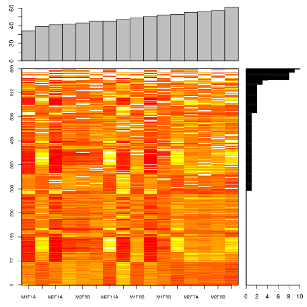

Overview of missing values.

```r
naplot(naset)
```

The importance of missing values in a dataset will depend on the quantitation technology employed. Label-free quantitation in particular can suffer from a very high number of missing values.

Missing value in `MSnSet` instances can be filtered out with the `filterNA` functions. By default, it removes features that contain at least `NA` value.

```r
## remove features with missing values
tmp <- filterNA(naset)
processingData(tmp)
```

```
## - - - Processing information - - -
## Subset [689,16][301,16] Wed Jul 11 08:58:38 2018
## Removed features with more than 0 NAs: Wed Jul 11 08:58:38 2018
## Dropped featureData's levels Wed Jul 11 08:58:38 2018
##  MSnbase version: 1.15.6
```

It is of course possible to impute missing values (`?impute`). This is however not a straightforward thing, as is likely to dramatically fail when a high proportion of data is missing (10s of %). But also, there are two types of mechanisms resulting in missing values in LC/MSMS experiments.

Note that when using *limma* for instance, downstream analyses can handle missing values. Still, it is recommended to explore missingness as part of the exploratory data analysis.

- Missing values resulting from absence of detection of a feature, despite ions being present at detectable concentrations. For example in the case of ion suppression or as a result from the stochastic, data-dependent nature of the MS acquisition method. These missing value are expected to be randomly distributed in the data and are defined as **missing at random** (MAR) or **missing completely at random** (MCAR).
- Biologically relevant missing values, resulting from the *absence* or the low abundance of ions (below the limit of detection of the instrument). These missing values are not expected to be randomly distributed in the data and are defined as **missing not at random** (MNAR).

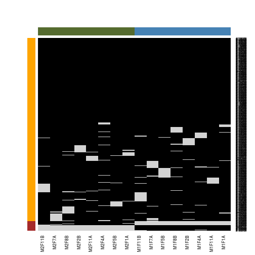

Random and non-random missing values.

Different imputation methods are more appropriate to different classes of missing values (as documented in this [paper](http://pubs.acs.org/doi/abs/10.1021/acs.jproteome.5b00981)). Values missing at random, and those missing not at random should be imputed with different methods.

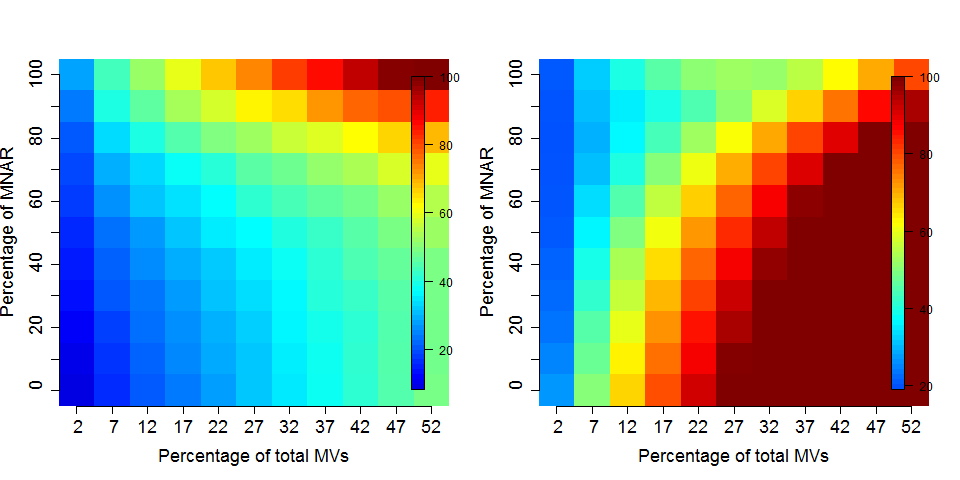

Root-mean-square error (RMSE) observations standard deviation ratio (RSR), KNN and MinDet imputation. Lower (blue) is better. (See [here](http://pubs.acs.org/doi/abs/10.1021/acs.jproteome.5b00981) for details)

Generally, it is recommended to use **hot deck** methods (nearest neighbour (**left**), maximum likelihood, …) when data are missing at random.Conversely, MNAR features should ideally be imputed with a **left-censor** (minimum value (**right**), but not zero, …) method.

```r
## impute missing values using knn imputation
tmp <- impute(naset, method = "knn")
processingData(tmp)
```

```
## - - - Processing information - - -
## Data imputation using knn Wed Jul 11 08:58:39 2018
##   Using default parameters
##  MSnbase version: 1.15.6
```

There are various methods to perform data imputation, as described in `?impute`.

# 8 Statistical analysis

R in general and Bioconductor in particular are well suited for the statistical analysis of data of quantitative proteomics data. Several packages provide dedicated resources for proteomics data:

- *MSstats*: A set of tools for statistical relative protein significance analysis in Data dependent (DDA), SRM and Data independent acquisition (DIA) experiments. Data stored in `data.frame` or `MSnSet` objects can be used as input.
- *msmsTests*: Statistical tests for label-free LC-MS/MS data by spectral counts, to discover differentially expressed proteins between two biological conditions. Three tests are available: Poisson GLM regression, quasi-likelihood GLM regression, and the negative binomial of the *edgeR* package. All can be readily applied on `MSnSet` instances produced, for example by `MSnID`.
- *isobar* also provides dedicated infrastructure for the statistical analysis of isobaric data.
- *DEP* provides an integrated analysis workflow for the analysis of mass spectrometry proteomics data for differential protein expression or differential enrichment.

# 9 Machine learning

The *MLInterfaces* package provides a unified interface to a wide range of machine learning algorithms. Initially developed for microarray and `ExpressionSet` instances, the *pRoloc* package enables application of these algorithms to `MSnSet` data.

## 9.1 Dimensionality reduction

Dimensionality reduction is very frequently used to summarise high-dimensional data. Below we will use principal component analysis (PCA), but other methods can be applied. Below, we will use the `plot2D` function from the *pRoloc* package, that will extract the expression values in the assay data, perform dimensionality reduction, an produce the scatter plot.

While originally developed for the analysis of spatial/organelle proteomics data in mind, it is applicable many use cases.

Let’s first use `plot2D` to visualise the pattern in 20 protein quantitation values (initial 20 dimensional data). Here, we use an example from spatial proteomics, where the quantitative protein profiles reflect the proteins sub-cellular localisation (from [Christoforou *et al*, 2016](https://www.nature.com/articles/ncomms9992), see also [Breckels *et al*, 2016](https://f1000research.com/articles/5-2926/) for more data analysis background). We will use the known localisation of some proteins (marker proteins) to annotate the plot (using the `fcol` argument).

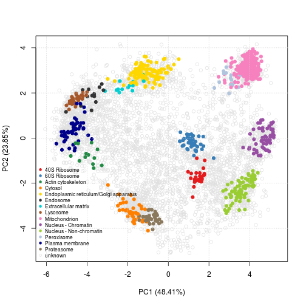

PCA plot for protein sub-cellular localisation.

```r
library("pRoloc")
library("pRolocdata")
data(hyperLOPIT2015)
plot2D(hyperLOPIT2015, fcol = "markers")
addLegend(hyperLOPIT2015, fcol = "markers", cex = .7)
```

In other cases, we want to visualise the relation of samples. `plot2D` uses the rows of the data to perform dimensionality reduction. To use the columns, we just need to transpose the `MSnSet`. By doing so, the `pData` becomes the `fData` and vice versa.

Let’s use a time-course experiment on stem cells ([Mulvey *et al.* 2015](https://www.ncbi.nlm.nih.gov/pubmed/26059426)). Below, we use the `times` (time points) variable to set colours and `rep` (replicate numbers) to set the plotting characters.

```r
data(mulvey2015)
head(pData(mulvey2015))
```

```
##           rep times cond
## rep1_0hr    1     1    1
## rep1_16hr   1     2    1
## rep1_24hr   1     3    1
## rep1_48hr   1     4    1
## rep1_72hr   1     5    1
## rep1_XEN    1     6    1
```

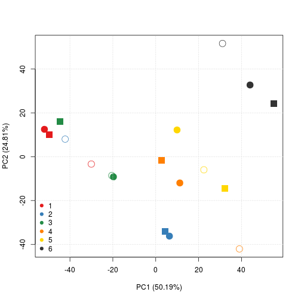

PCA plots for sample in a time-course experiment.

```r
plot2D(t(mulvey2015),  fcol = "times", fpch = "rep", cex = 2)
addLegend(t(mulvey2015),  fcol = "times")
```

## 9.2 Classification

The example below uses `knn` with the 5 closest neighbours and the *MLInterfaces* package as an illustration to classify proteins of unknown sub-cellular localisation to one of 9 possible organelles.

```r
library("MLInterfaces")
library("pRolocdata")
data(dunkley2006)
traininds <- which(fData(dunkley2006)$markers != "unknown")
ans <- MLearn(markers ~ ., data = t(dunkley2006), knnI(k = 5), traininds)
ans
```

```
## MLInterfaces classification output container
## The call was:
## MLearn(formula = markers ~ ., data = t(dunkley2006), .method = knnI(k = 5),
##     trainInd = traininds)
## Predicted outcome distribution for test set:
##
##      ER lumen   ER membrane         Golgi Mitochondrion       Plastid
##             5           140            67            51            29
##            PM      Ribosome           TGN       vacuole
##            89            31             6            10
## Summary of scores on test set (use testScores() method for details):
##    Min. 1st Qu.  Median    Mean 3rd Qu.    Max.
##  0.4000  1.0000  1.0000  0.9332  1.0000  1.0000
```

## 9.3 Clustering

A wide range of classification and clustering algorithms are also available, as described in the `?MLearn` documentation page, used below.

```r
kcl <- MLearn( ~ ., data = dunkley2006, kmeansI, centers = 12)
kcl
```

```
## clusteringOutput: partition table
##
##   1   2   3   4   5   6   7   8   9  10  11  12
##  55  28  29  18  60  30  44 145  78 116  33  53
## The call that created this object was:
## MLearn(formula = ~., data = dunkley2006, .method = kmeansI, centers = 12)
```

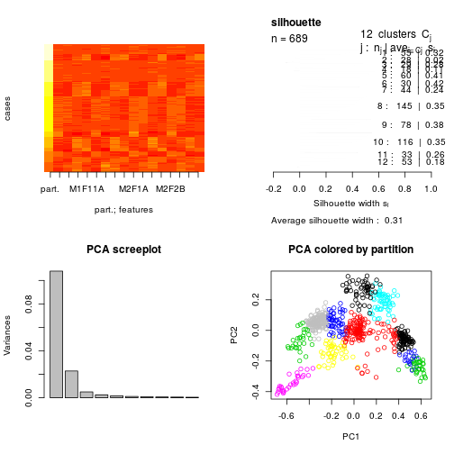

```r
plot(kcl, exprs(dunkley2006))
```

# 10 Annotation

All the [Bioconductor annotation infrastructure](http://bioconductor.org/help/workflows/annotation/Annotation_Resources/), such as *biomaRt*, *GO.db*, organism specific annotations, .. are directly relevant to the analysis of proteomics data. A total of 191 ontologies, including some proteomics-centred annotations such as the PSI Mass Spectrometry Ontology, Molecular Interaction (PSI MI 2.5) or Protein Modifications are available through the *rols*

```r
library("rols")
res <- OlsSearch(q = "ESI", ontology = "MS", exact = TRUE)
res
```

```
## Object of class 'OlsSearch':
##   ontolgy: MS
##   query: ESI
##   requested: 20 (out of 1)
##   response(s): 0
```

There is a single exact match (default is to retrieve 20 results), that can be retrieved and coerced to a `Terms` or `data.frame` object with

```r
res <- olsSearch(res)
as(res, "Terms")
```

```
## Object of class 'Terms' with 1 entries
##  From the MS ontology
## MS:1000073
```

```r
as(res, "data.frame")
```

```
##                                                   id
## 1 ms:class:http://purl.obolibrary.org/obo/MS_1000073
##                                         iri short_form     obo_id
## 1 http://purl.obolibrary.org/obo/MS_1000073 MS_1000073 MS:1000073
##                     label
## 1 electrospray ionization
##                                                                                                                                                                                                                                                                                                          …
## 1 A process in which ionized species in the gas phase are produced from an analyte-containing solution via highly charged fine droplets, by means of spraying the solution from a narrow-bore needle tip at atmospheric pressure in the presence of a high electric field. When a pressurized gas is used…
##   ontology_name ontology_prefix  type is_defining_ontology
## 1            ms              MS class                 TRUE
```

Data from the [Human Protein Atlas](http://www.proteinatlas.org/) is available via the *hpar* package.

# 11 More information

## 11.1 References and resources

- [Visualisation of proteomics data using R and Bioconductor](http://www.ncbi.nlm.nih.gov/pmc/articles/PMC4510819/)
- [Using R and Bioconductor for proteomics data analysis](http://arxiv.org/pdf/1305.6559v1.pdf)
- `RforProteomics`: http://bioconductor.org/packages/RforProteomics

## 11.2 Other relevant packages/pipelines

- Analysis of post translational modification with *isobar*.
- Processing and analysis or isobaric tagging mass spectrometry with *isobar* and *MSnbase*.
- Analysis of spatial proteomics data and, more generally, supervised, semi-supervised learning, and [transfer learning](https://www.ncbi.nlm.nih.gov/pubmed/23523639) using the *pRoloc* package.
- Analysis of MALDI data with the *MALDIquant* package.
- Access to the Proteomics Standard Initiative Common QUery InterfaCe with the *PSICQUIC* package.
- *Cardinal*: A mass spectrometry imaging toolbox for statistical analysis.
- *MSnID*: Utilities for Exploration and Assessment of Confidence of LC-MSn Proteomics Identifications.
- *protViz*: Visualising and Analysing Mass Spectrometry Related Data in Proteomics
- *aLFQ*: Estimating Absolute Protein Quantities from Label-Free LC-MS/MS Proteomics Data.
- *protiq*: Protein (identification and) quantification based on peptide evidence.
- *MSstats*: Protein Significance Analysis in DDA, SRM and DIA for Label-free or Label-based Proteomics Experiments

### Data Independent Acquisition

- Analysis of label-free data from a Synapt G2 (including ion mobility) with *synapter*.
- *SWATH2stats*: Transform and Filter SWATH Data for Statistical Packages and
- *specL*: Prepare Peptide Spectrum Matches for Use in Targeted Proteomics
- *SwathXtend*: SWATH extended library generation and statistical data analysis